# Correlation of Carbon Emissions and Tree Cover Loss in the USA

Authors

Cecily Sperber

Libby Prince

Brandon Pizer

# Introduction

# Background

Deforestation and forest degradation are major contributors to climate change because they release carbon stored in trees. Forests serve as vital carbon sinks, according to Bastin et al. (2019) sequestering CO₂ from the atmosphere through photosynthesis). When trees are cut down, burned, or otherwise destroyed, this stored carbon is released into the atmosphere, contributing to the greenhouse effect and rising global temperatures states Curtis et al. (2018). As one of the top carbon-emitting countries, the United States has a responsibility to mitigate emissions through land management and forest conservation. Climate change is one of the most pressing global issues of the 21st century. While there are many causes, the rise in carbon dioxide (CO₂) in the atmosphere is known to be the main driver of human-caused climate change (EPA, 2023). Carbon dioxide is a greenhouse gas, meaning it traps heat in the atmosphere. This leads to warmer global temperatures, changes in weather patterns, and rising sea levels. To understand these impacts, scientists study the carbon cycle, especially the role of forests, which act as a natural carbon sink by absorbing CO₂. However, when forests are destroyed or degraded, their ability to absorb carbon is reduced, and often, carbon is sent back into the atmosphere (Pan et al., 2011). This project examines the connection between carbon dioxide emissions and tree cover loss in the United States from 2001 to 2016. We focus on whether yearly forest loss is related to changes in CO₂ levels in the atmosphere. The goal is to better understand how deforestation affects the carbon balance in a country that significantly influences global emissions and conservation.

# Motivation

The United States is one of the world’s largest carbon emitters and large areas of forested land. Deforestation and land-use changes have contributed significantly to CO₂ emissions, making up about a third of global emissions from 1750 to 2011 and 12% between 2000 and 2009 according to Adopted (2014). In the U.S., the climate effects of forest loss are often less noticeable or prioritized than in tropical regions. While deforestation in areas like the Amazon is a major focus in global environmental discussions, the impact of forest loss in the U.S. is less frequently studied. This project aims to explore how forest loss in the U.S. influences CO₂ emissions and the country’s carbon balance. This study is motivated to better understand how U.S. forest ecosystems affect the carbon cycle and how protecting forests can help mitigate climate change. Understanding the effects of land-use change is essential to achieving greenhouse gas reduction goals. If strong correlations are found between tree cover loss and CO₂ levels, it could support the case for forest conservation policies and nature-based solutions like reforestation and improved forest management. Additionally, this research adds to the growing evidence that forests act as important carbon sinks. Forest conservation not only helps reduce emissions but also offers benefits like protecting biodiversity, managing water, and supporting ecosystem services. By analyzing the effects of forest loss on the U.S. carbon cycle, this study aims to develop more effective conservation strategies and climate policies that effectively address both immediate and long-term environmental challenges.

**Necessary Packages**

```r
library(tidyverse)
library(tidymodels)
library(usethis)
```

# Data

For our project, we worked with two datasets: one containing carbon emissions data and another with tree cover loss data. Below, we describe the origin, cleaning, and manipulation of the data, followed by three visualizations that help us explore potential patterns We used global atmospheric carbon dioxide (CO₂) data from the National Oceanic and Atmospheric Administration (NOAA). This dataset included monthly values of CO₂ concentrations, specifically the “Seasonally Adjusted CO2 Fit (ppm)” column. And for the Tree Cover Loss Data we collected the dataset from Global Forest Watch and it includes worldwide estimates of annual forest cover in hectares.

```r
carbon_data <- read_csv("C:/ESS330/lab7/data/carbon.csv")
treecover_data <- read_csv("C:/ESS330/lab7/data/treecover.csv")
```

# Methods

This project uses a combination of data cleaning, visualization, and basic statistical analysis to examine the relationship between carbon dioxide concentrations and tree cover loss in the United States from 2001 to 2016. The primary goal is to assess whether a measurable correlation exists between annual CO₂ levels and the amount of tree cover lost in the same years. After joining the datasets, separate plots are created for carbon dioxide and tree loss individually, and then a dual-axis plot is designed to observe both variables together. This visual comparison helps identify whether the patterns in CO₂ levels and tree loss appear to be linked in any consistent way over time. To evaluate the relationship statistically, a correlation analysis (e.g., Pearson correlation coefficient) and a Shapiro test will be conducted. One potential challenge is that carbon dioxide concentrations reflect global atmospheric conditions, not just emissions or carbon sinks within the United States. While the CO₂ dataset is valuable and accurate, it may not respond exclusively to tree cover loss in the U.S., especially given the global nature of carbon mixing in the atmosphere. This could obscure the direct correlation between U.S. forest loss and atmospheric CO₂ levels. Additionally, the tree cover loss data does not distinguish between temporary and permanent loss. Some tree loss may be due to natural events or sustainable forestry practices followed by replanting, meaning the carbon released is not necessarily permanent. Without knowing the context of each year’s tree loss, it is difficult to estimate the true carbon impact of those changes. The correlation and regression methods used in this project are relatively simple and cannot account for complex interactions between multiple climate and land use variables. For example, CO₂ levels are influenced by a wide range of factors, including industrial activity, transportation, and ocean absorption, not just forest loss. Therefore, a statistically significant correlation between the two variables does not prove causation, and results must be interpreted carefully. Furthermore, the 15-year time frame provides a limited number of data points (n = 16), which can reduce statistical power and make it more difficult to detect subtle trends. If the relationship is weak or non-linear, more advanced time-series analysis or larger datasets may be needed to fully understand the dynamics at play. Despite the limitations, the selected methods are well-suited for the initial goals of this project. The use of line graphs and dual-axis plots allows for a clear visual comparison of two key environmental indicators, while the correlation coefficient provides a first step toward understanding whether a statistical relationship exists. The scale of the data is also well-suited for the correlation analysis. These approaches are appropriate for an exploratory study and can help guide further questions or more complex modeling if a clear pattern is observed. Ultimately, the goal of this analysis is not to claim a definitive causal link but to explore whether patterns in forest loss and carbon emissions are moving together in a way that supports further investigation. If a strong correlation is found, it could support the argument that U.S. forest protection is an important component of national climate strategies. If no correlation is found, that result is still valuable in showing the complexity of climate systems and the importance of using multi-factor analysis in environmental research.

# Data Cleaning

```r
library(tidyverse)
library(tidymodels)
library(usethis)

# Tree Data
cleaned_tree_data <- treecover_data %>%
  filter(iso == "USA", year >= 2001, year <= 2016)

head(cleaned_tree_data)
```

```
# A tibble: 6 × 3
  iso    year loss__ha
  <chr> <dbl>    <dbl>
1 USA    2001 1943319.
2 USA    2002 2038436.
3 USA    2003 1649384.
4 USA    2004 2746257.
5 USA    2005 2691544.
6 USA    2006 2605856.
```

To clean the carbon dataset we removed unnecessary columns and kept only Year, Month, and Seasonally Adjusted CO2 Fit (ppm). We also filtered the data to include only the years from 2001 to 2016. Then we grouped the monthly values by year and calculated the annual average CO₂ level to simplify the analysis.

```r
# Carbon Data
cleaned_carbon_data <- carbon_data |>
  select(year = Year, Month, CO2 = `Seasonally Adjusted CO2 Fit (ppm)`) |>
  filter(year >= 2001, year <= 2016) |>
  group_by(year) |>
  summarise(Yearly_Mean = mean(CO2), na.rm = TRUE) |>
  ungroup()
```

# Joining Data

```r
joined_data <- inner_join(cleaned_carbon_data, cleaned_tree_data, by = "year")
view(joined_data)
```

# Shaprio Test

```r
shapiro_co2 <- shapiro.test(joined_data$Yearly_Mean)
shapiro_tree <- shapiro.test(joined_data$loss__ha)

shapiro_co2
```

```
    Shapiro-Wilk normality test

data:  joined_data$Yearly_Mean
W = 0.971, p-value = 0.8545
```

```r
shapiro_tree
```

```
    Shapiro-Wilk normality test

data:  joined_data$loss__ha
W = 0.93401, p-value = 0.282
```

# Correlation Test

```r
cor.test(joined_data$Yearly_Mean, joined_data$loss__ha, method = "pearson")
```

```
    Pearson's product-moment correlation

data:  joined_data$Yearly_Mean and joined_data$loss__ha
t = -0.7376, df = 14, p-value = 0.4729
alternative hypothesis: true correlation is not equal to 0
95 percent confidence interval:
 -0.6288267  0.3343514
sample estimates:
       cor
-0.1934096
```

# Plot Carbon Data

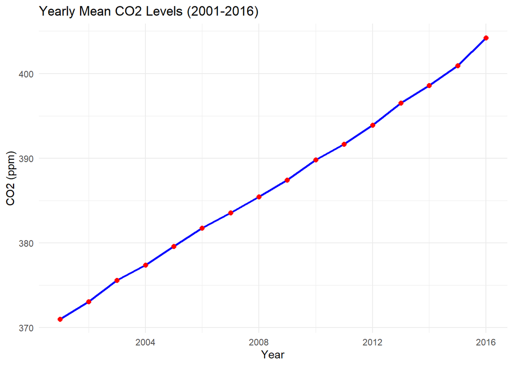

```r
ggplot(cleaned_carbon_data, aes(x = year, y = Yearly_Mean)) +
  geom_line(color = "blue", size = 1) +
  geom_point(color = "red", size = 2) +
  labs(
    title = "Yearly Mean CO2 Levels (2001-2016)",
    x = "Year",
    y = "CO2 (ppm)"
  ) +
  theme_minimal()
```

## Graph 1: Yearly Mean CO₂ Levels (2001–2016)

Graph 1 displays the average annual CO₂ concentration in the atmosphere over time. A clear upward trend highlights the increase in emissions over the selected years.

# Plot Tree Data

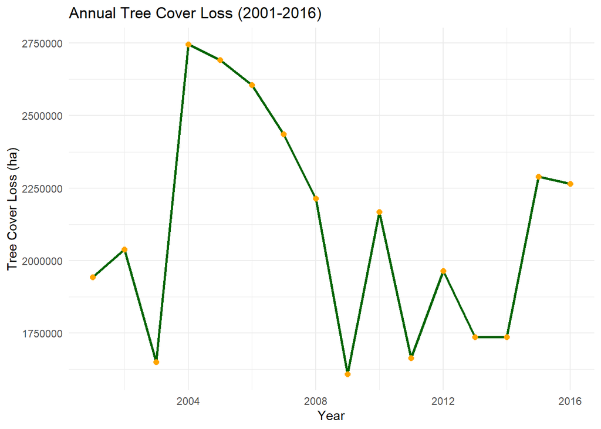

```r
ggplot(joined_data, aes(x = year, y = loss__ha)) +
  geom_line(color = "darkgreen", size = 1) +
  geom_point(color = "orange", size = 2) +
  labs(
    title = "Annual Tree Cover Loss (2001-2016)",
    x = "Year",
    y = "Tree Cover Loss (ha)"
  ) +
  theme_minimal()
```

## Graph 2: Annual Tree Cover Loss in the USA (2001–2016)

Graph 2 shows how tree cover loss has varied across the same time period. Peaks in certain years may indicate significant deforestation events or natural disturbances such as wildfires or storms.

# Plot Tree Loss and Carbon

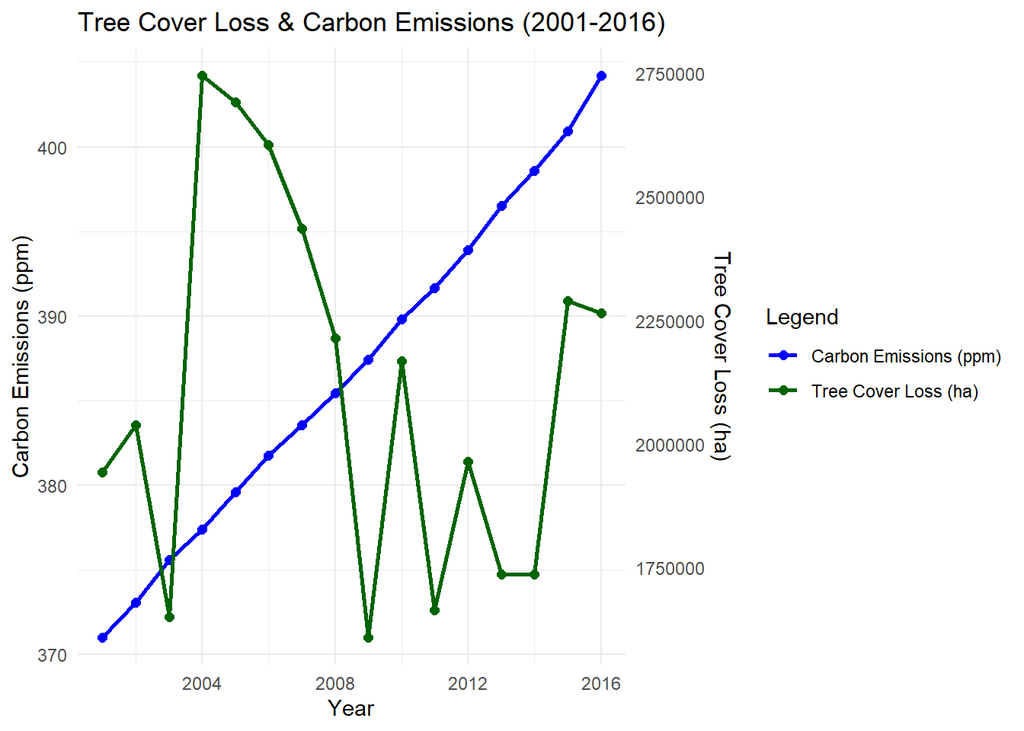

```r
library(scales)

plot_data <- joined_data %>%
  select(year, Yearly_Mean, loss__ha) %>%
  pivot_longer(cols = c(Yearly_Mean, loss__ha),
               names_to = "Variable",
               values_to = "Value")

joined_data <- joined_data %>%
  mutate(scaled_loss = rescale(loss__ha, to = range(Yearly_Mean, na.rm = TRUE)))

ggplot() +
  geom_line(data = joined_data, aes(x = year, y = Yearly_Mean, color = "Carbon Emissions (ppm)"), size = 1) +
  geom_point(data = joined_data, aes(x = year, y = Yearly_Mean, color = "Carbon Emissions (ppm)"), size = 2) +
  geom_line(data = joined_data, aes(x = year, y = scaled_loss, color = "Tree Cover Loss (ha)"), size = 1) +
  geom_point(data = joined_data, aes(x = year, y = scaled_loss, color = "Tree Cover Loss (ha)"), size = 2) +
  scale_y_continuous(
    name = "Carbon Emissions (ppm)",
    sec.axis = sec_axis(~rescale(., from = range(joined_data$Yearly_Mean, na.rm = TRUE),
                                    to = range(joined_data$loss__ha, na.rm = TRUE)),
                        name = "Tree Cover Loss (ha)")
  ) +
  scale_color_manual(values = c("Carbon Emissions (ppm)" = "blue", "Tree Cover Loss (ha)" = "darkgreen")) +
  labs(
    title = "Tree Cover Loss & Carbon Emissions (2001-2016)",
    x = "Year",
    color = "Legend"
  ) +
  theme_minimal()
```

## Graph 3: Correlation of Tree Cover Loss and CO₂ Emissions (2001-2016)

Graph 3 explores the potential relationships between forest loss and atmospheric carbon levels. We created a dual-axis graph for both tree cover loss (scaled to match the range of CO₂) and CO₂ levels which are plotted together by year. This visualization helps us visually assess whether higher deforestation years might be associated with increased carbon emissions.

## References

Adopted, IPCC. 2014. “Climate Change 2014 Synthesis Report.” *IPCC: Geneva, Szwitzerland*, 1059–72.

Bastin, Jean-Francois, Yelena Finegold, Claude Garcia, Danilo Mollicone, Marcelo Rezende, Devin Routh, Constantin M Zohner, and Thomas W Crowther. 2019. “The Global Tree Restoration Potential.” *Science* 365 (6448): 76–79.

Curtis, Philip G, Christy M Slay, Nancy L Harris, Alexandra Tyukavina, and Matthew C Hansen. 2018. “Classifying Drivers of Global Forest Loss.” *Science* 361 (6407): 1108–11.

Pan, Yude, Richard A Birdsey, Jingyun Fang, Richard Houghton, Pekka E Kauppi, Werner A Kurz, Oliver L Phillips, et al. 2011. “A Large and Persistent Carbon Sink in the World’s Forests.” *Science* 333 (6045): 988–93.